# Basic Example

Fiorella Sandoval

2025-10-01

#La Tarea esta en la línea 199

# Librerias

```r
library(ggplot2)
library(dplyr)
```

# Letura de datos

```r
data_path <- file.path("C:/Users/Family2/Documents/4SEMESTRE/Estadistica_IV/UNIDAD_1/020_Tarea")
data_file <- file.path(data_path, "vgsales.csv")
data.vg.raw <- read.csv(data_file,
                 stringsAsFactors = F,na.strings = ".",header = T,sep=",")
head(data.vg.raw)
```

```
##   Rank                     Name Platform Year        Genre Publisher NA_Sales
## 1    1               Wii Sports      Wii 2006       Sports  Nintendo    41.49
## 2    2        Super Mario Bros.      NES 1985     Platform  Nintendo    29.08
## 3    3           Mario Kart Wii      Wii 2008       Racing  Nintendo    15.85
## 4    4        Wii Sports Resort      Wii 2009       Sports  Nintendo    15.75
## 5    5 Pokemon Red/Pokemon Blue       GB 1996 Role-Playing  Nintendo    11.27
## 6    6                   Tetris       GB 1989       Puzzle  Nintendo    23.20
##   EU_Sales JP_Sales Other_Sales Global_Sales
## 1    29.02     3.77        8.46        82.74
## 2     3.58     6.81        0.77        40.24
## 3    12.88     3.79        3.31        35.82
## 4    11.01     3.28        2.96        33.00
## 5     8.89    10.22        1.00        31.37
## 6     2.26     4.22        0.58        30.26
```

```r
str(data.vg.raw)
```

```
## 'data.frame':    16598 obs. of  11 variables:
##  $ Rank        : int  1 2 3 4 5 6 7 8 9 10 ...
##  $ Name        : chr  "Wii Sports" "Super Mario Bros." "Mario Kart Wii" "Wii Sports Resort" ...
##  $ Platform    : chr  "Wii" "NES" "Wii" "Wii" ...
##  $ Year        : chr  "2006" "1985" "2008" "2009" ...
##  $ Genre       : chr  "Sports" "Platform" "Racing" "Sports" ...
##  $ Publisher   : chr  "Nintendo" "Nintendo" "Nintendo" "Nintendo" ...
##  $ NA_Sales    : num  41.5 29.1 15.8 15.8 11.3 ...
##  $ EU_Sales    : num  29.02 3.58 12.88 11.01 8.89 ...
##  $ JP_Sales    : num  3.77 6.81 3.79 3.28 10.22 ...
##  $ Other_Sales : num  8.46 0.77 3.31 2.96 1 0.58 2.9 2.85 2.26 0.47 ...
##  $ Global_Sales: num  82.7 40.2 35.8 33 31.4 ...
```

# Limpieza de datos

```r
data.vg <- data.vg.raw
data.vg$Platform <- factor(data.vg$Platform)
data.vg$Year <- as.numeric(data.vg$Year)
summary(data.vg)
```

```
##       Rank           Name              Platform         Year
##  Min.   :    1   Length:16598       DS     :2163   Min.   :1980
##  1st Qu.: 4151   Class :character   PS2    :2161   1st Qu.:2003
##  Median : 8300   Mode  :character   PS3    :1329   Median :2007
##  Mean   : 8301                      Wii    :1325   Mean   :2006
##  3rd Qu.:12450                      X360   :1265   3rd Qu.:2010
##  Max.   :16600                      PSP    :1213   Max.   :2020
##                                     (Other):7142   NA's   :271
##     Genre            Publisher            NA_Sales          EU_Sales
##  Length:16598       Length:16598       Min.   : 0.0000   Min.   : 0.0000
##  Class :character   Class :character   1st Qu.: 0.0000   1st Qu.: 0.0000
##  Mode  :character   Mode  :character   Median : 0.0800   Median : 0.0200
##                                        Mean   : 0.2647   Mean   : 0.1467
##                                        3rd Qu.: 0.2400   3rd Qu.: 0.1100
##                                        Max.   :41.4900   Max.   :29.0200
##
##     JP_Sales         Other_Sales        Global_Sales
##  Min.   : 0.00000   Min.   : 0.00000   Min.   : 0.0100
##  1st Qu.: 0.00000   1st Qu.: 0.00000   1st Qu.: 0.0600
##  Median : 0.00000   Median : 0.01000   Median : 0.1700
##  Mean   : 0.07778   Mean   : 0.04806   Mean   : 0.5374
##  3rd Qu.: 0.04000   3rd Qu.: 0.04000   3rd Qu.: 0.4700
##  Max.   :10.22000   Max.   :10.57000   Max.   :82.7400
##
```

```r
str(data.vg.raw)
```

```
## 'data.frame':    16598 obs. of  11 variables:
##  $ Rank        : int  1 2 3 4 5 6 7 8 9 10 ...
##  $ Name        : chr  "Wii Sports" "Super Mario Bros." "Mario Kart Wii" "Wii Sports Resort" ...
##  $ Platform    : chr  "Wii" "NES" "Wii" "Wii" ...
##  $ Year        : chr  "2006" "1985" "2008" "2009" ...
##  $ Genre       : chr  "Sports" "Platform" "Racing" "Sports" ...
##  $ Publisher   : chr  "Nintendo" "Nintendo" "Nintendo" "Nintendo" ...
##  $ NA_Sales    : num  41.5 29.1 15.8 15.8 11.3 ...
##  $ EU_Sales    : num  29.02 3.58 12.88 11.01 8.89 ...
##  $ JP_Sales    : num  3.77 6.81 3.79 3.28 10.22 ...
##  $ Other_Sales : num  8.46 0.77 3.31 2.96 1 0.58 2.9 2.85 2.26 0.47 ...
##  $ Global_Sales: num  82.7 40.2 35.8 33 31.4 ...
```

```r
unique(data.vg.raw$Year)
```

```
##  [1] "2006" "1985" "2008" "2009" "1996" "1989" "1984" "2005" "1999" "2007"
## [11] "2010" "2013" "2004" "1990" "1988" "2002" "2001" "2011" "1998" "2015"
## [21] "2012" "2014" "1992" "1997" "1993" "1994" "1982" "2003" "1986" "2000"
## [31] "N/A"  "1995" "2016" "1991" "1981" "1987" "1980" "1983" "2020" "2017"
```

```r
head(filter(data.vg.raw, Year=="N/A"))
```

```
##   Rank                       Name Platform Year    Genre
## 1  180            Madden NFL 2004      PS2  N/A   Sports
## 2  378           FIFA Soccer 2004      PS2  N/A   Sports
## 3  432 LEGO Batman: The Videogame      Wii  N/A   Action
## 4  471 wwe Smackdown vs. Raw 2006      PS2  N/A Fighting
## 5  608             Space Invaders     2600  N/A  Shooter
## 6  625                  Rock Band     X360  N/A     Misc
##                                Publisher NA_Sales EU_Sales JP_Sales Other_Sales
## 1                        Electronic Arts     4.26     0.26     0.01        0.71
## 2                        Electronic Arts     0.59     2.36     0.04        0.51
## 3 Warner Bros. Interactive Entertainment     1.86     1.02     0.00        0.29
## 4                                    N/A     1.57     1.02     0.00        0.41
## 5                                  Atari     2.36     0.14     0.00        0.03
## 6                        Electronic Arts     1.93     0.34     0.00        0.21
##   Global_Sales
## 1         5.23
## 2         3.49
## 3         3.17
## 4         3.00
## 5         2.53
## 6         2.48
```

```r
unique(data.vg$Platform)
```

```
##  [1] Wii  NES  GB   DS   X360 PS3  PS2  SNES GBA  3DS  PS4  N64  PS   XB   PC
## [16] 2600 PSP  XOne GC   WiiU GEN  DC   PSV  SAT  SCD  WS   NG   TG16 3DO  GG
## [31] PCFX
## 31 Levels: 2600 3DO 3DS DC DS GB GBA GC GEN GG N64 NES NG PC PCFX PS ... XOne
```

```r
filter(data.vg, Name=="FIFA 15")
```

```
##   Rank    Name Platform Year  Genre       Publisher NA_Sales EU_Sales JP_Sales
## 1  125 FIFA 15      PS4 2014 Sports Electronic Arts     0.79     4.29     0.05
## 2  220 FIFA 15      PS3 2014 Sports Electronic Arts     0.57     3.14     0.04
## 3  450 FIFA 15     X360 2014 Sports Electronic Arts     0.78     2.02     0.00
## 4  762 FIFA 15     XOne 2014 Sports Electronic Arts     0.60     1.41     0.00
## 5 2477 FIFA 15      PSV 2014 Sports Electronic Arts     0.13     0.48     0.04
## 6 2718 FIFA 15      Wii 2014 Sports Electronic Arts     0.24     0.46     0.00
## 7 4370 FIFA 15      3DS 2014 Sports Electronic Arts     0.09     0.33     0.00
## 8 5913 FIFA 15       PC 2014 Sports Electronic Arts     0.00     0.27     0.00
##   Other_Sales Global_Sales
## 1        1.47         6.59
## 2        1.07         4.82
## 3        0.30         3.11
## 4        0.14         2.15
## 5        0.19         0.84
## 6        0.06         0.76
## 7        0.03         0.45
## 8        0.03         0.30
```

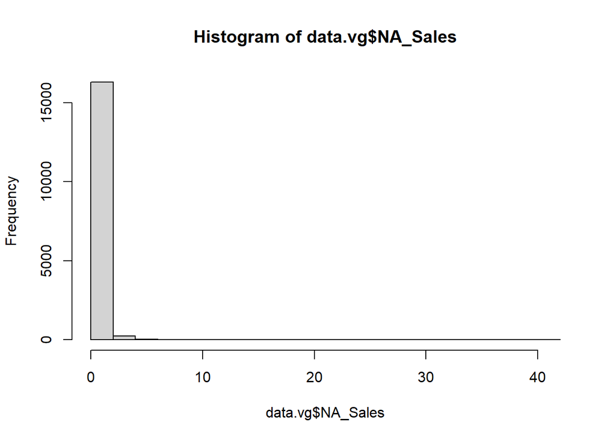

```r
hist(data.vg$NA_Sales )
```

Calculemos la proporcion de los datos missings Esto nos ayudará a decidir la estrategia (borrar vs. llenar)

```r
# Contar NA por columna
na_por_columna <- colSums(is.na(data.vg))
print("NA por columna:")
```

```
## [1] "NA por columna:"
```

```r
print(na_por_columna)
```

```
##         Rank         Name     Platform         Year        Genre    Publisher
##            0            0            0          271            0            0
##     NA_Sales     EU_Sales     JP_Sales  Other_Sales Global_Sales
##            0            0            0            0            0
```

```r
# Porcentaje de NA por columna
porcentaje_na <- colMeans(is.na(data.vg)) * 100
print("Porcentaje de NA por columna:")
```

```
## [1] "Porcentaje de NA por columna:"
```

```r
print(round(porcentaje_na, 2))
```

```
##         Rank         Name     Platform         Year        Genre    Publisher
##         0.00         0.00         0.00         1.63         0.00         0.00
##     NA_Sales     EU_Sales     JP_Sales  Other_Sales Global_Sales
##         0.00         0.00         0.00         0.00         0.00
```

```r
length(unique(data.vg$Publisher))
```

```
## [1] 579
```

```r
filter(data.vg, Publisher==" ")
```

```
##  [1] Rank         Name         Platform     Year         Genre
##  [6] Publisher    NA_Sales     EU_Sales     JP_Sales     Other_Sales
## [11] Global_Sales
## <0 linhas> (ou row.names de comprimento 0)
```

Este reporte lo veré en GITHUB

```r
# DataFrame de ejemplo con missing values

print("DataFrame original:")
```

```
## [1] "DataFrame original:"
```

```r
print(head(data.vg))
```

```
##   Rank                     Name Platform Year        Genre Publisher NA_Sales
## 1    1               Wii Sports      Wii 2006       Sports  Nintendo    41.49
## 2    2        Super Mario Bros.      NES 1985     Platform  Nintendo    29.08
## 3    3           Mario Kart Wii      Wii 2008       Racing  Nintendo    15.85
## 4    4        Wii Sports Resort      Wii 2009       Sports  Nintendo    15.75
## 5    5 Pokemon Red/Pokemon Blue       GB 1996 Role-Playing  Nintendo    11.27
## 6    6                   Tetris       GB 1989       Puzzle  Nintendo    23.20
##   EU_Sales JP_Sales Other_Sales Global_Sales
## 1    29.02     3.77        8.46        82.74
## 2     3.58     6.81        0.77        40.24
## 3    12.88     3.79        3.31        35.82
## 4    11.01     3.28        2.96        33.00
## 5     8.89    10.22        1.00        31.37
## 6     2.26     4.22        0.58        30.26
```

```r
cat("Filas originales:", nrow(data.vg), "\n\n")
```

```
## Filas originales: 16598
```

```r
# Método 1: na.omit() - Elimina filas con cualquier NA
df_sin_na <- na.omit(data.vg)
print("Con na.omit():")
```

```
## [1] "Con na.omit():"
```

```r
print(head(df_sin_na))
```

```
##   Rank                     Name Platform Year        Genre Publisher NA_Sales
## 1    1               Wii Sports      Wii 2006       Sports  Nintendo    41.49
## 2    2        Super Mario Bros.      NES 1985     Platform  Nintendo    29.08
## 3    3           Mario Kart Wii      Wii 2008       Racing  Nintendo    15.85
## 4    4        Wii Sports Resort      Wii 2009       Sports  Nintendo    15.75
## 5    5 Pokemon Red/Pokemon Blue       GB 1996 Role-Playing  Nintendo    11.27
## 6    6                   Tetris       GB 1989       Puzzle  Nintendo    23.20
##   EU_Sales JP_Sales Other_Sales Global_Sales
## 1    29.02     3.77        8.46        82.74
## 2     3.58     6.81        0.77        40.24
## 3    12.88     3.79        3.31        35.82
## 4    11.01     3.28        2.96        33.00
## 5     8.89    10.22        1.00        31.37
## 6     2.26     4.22        0.58        30.26
```

```r
cat("Filas después de na.omit():", nrow(df_sin_na), "\n\n")
```

```
## Filas después de na.omit(): 16327
```

```r
# Método 2: complete.cases() - Más control
df_completo <- data.vg[complete.cases(data.vg), ]
print("Con complete.cases():")
```

```
## [1] "Con complete.cases():"
```

```r
print(head(df_completo))
```

```
##   Rank                     Name Platform Year        Genre Publisher NA_Sales
## 1    1               Wii Sports      Wii 2006       Sports  Nintendo    41.49
## 2    2        Super Mario Bros.      NES 1985     Platform  Nintendo    29.08
## 3    3           Mario Kart Wii      Wii 2008       Racing  Nintendo    15.85
## 4    4        Wii Sports Resort      Wii 2009       Sports  Nintendo    15.75
## 5    5 Pokemon Red/Pokemon Blue       GB 1996 Role-Playing  Nintendo    11.27
## 6    6                   Tetris       GB 1989       Puzzle  Nintendo    23.20
##   EU_Sales JP_Sales Other_Sales Global_Sales
## 1    29.02     3.77        8.46        82.74
## 2     3.58     6.81        0.77        40.24
## 3    12.88     3.79        3.31        35.82
## 4    11.01     3.28        2.96        33.00
## 5     8.89    10.22        1.00        31.37
## 6     2.26     4.22        0.58        30.26
```

```r
cat("Filas después de complete.cases():", nrow(df_completo), "\n")
```

```
## Filas después de complete.cases(): 16327
```

```r
data.vg  <- data.vg[complete.cases(data.vg), ]
dim(data.vg)
```

```
## [1] 16327    11
```

# Tendencia Central

```r
summary(data.vg$Global_Sales)
```

```
##    Min. 1st Qu.  Median    Mean 3rd Qu.    Max.
##  0.0100  0.0600  0.1700  0.5402  0.4800 82.7400
```

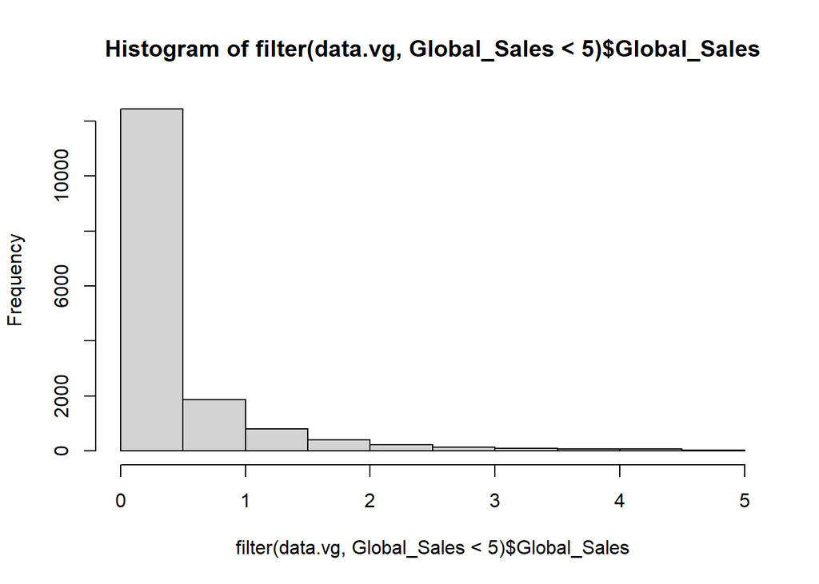

```r
hist(filter(data.vg,Global_Sales < 5)$Global_Sales)
```

```r
set.seed(13)
N <- dim(data.vg)[1]
indices_muestra <- sample(1:N,200,replace = TRUE)
data.muestra<-data.vg[indices_muestra, ]
summary(data.muestra$Global_Sales)
```

```
##    Min. 1st Qu.  Median    Mean 3rd Qu.    Max.
##   0.010   0.070   0.185   0.386   0.365   6.430
```

```r
summary(data.vg$Global_Sales)
```

```
##    Min. 1st Qu.  Median    Mean 3rd Qu.    Max.
##  0.0100  0.0600  0.1700  0.5402  0.4800 82.7400
```

```r
dim(filter(data.vg, Global_Sales<2))
```

```
## [1] 15486    11
```

```r
dim(data.vg)
```

```
## [1] 16327    11
```

```r
dim( filter(data.vg, Global_Sales<2) )[1]  /  dim(data.vg)[1]
```

```
## [1] 0.9484902
```

```r
data.vg.pobint <- filter(data.vg, Global_Sales<2)
summary(data.vg.pobint$Global_Sales)
```

```
##    Min. 1st Qu.  Median    Mean 3rd Qu.    Max.
##  0.0100  0.0600  0.1500  0.3124  0.4100  1.9900
```

```r
set.seed(10)
N <- dim(data.vg.pobint)[1]
indices_muestra <- sample(1:N,200,replace = TRUE)
data.muestra<-data.vg.pobint[indices_muestra, ]
summary(data.muestra$Global_Sales)
```

```
##    Min. 1st Qu.  Median    Mean 3rd Qu.    Max.
##  0.0100  0.0600  0.1600  0.3145  0.3950  1.9400
```

Graficos

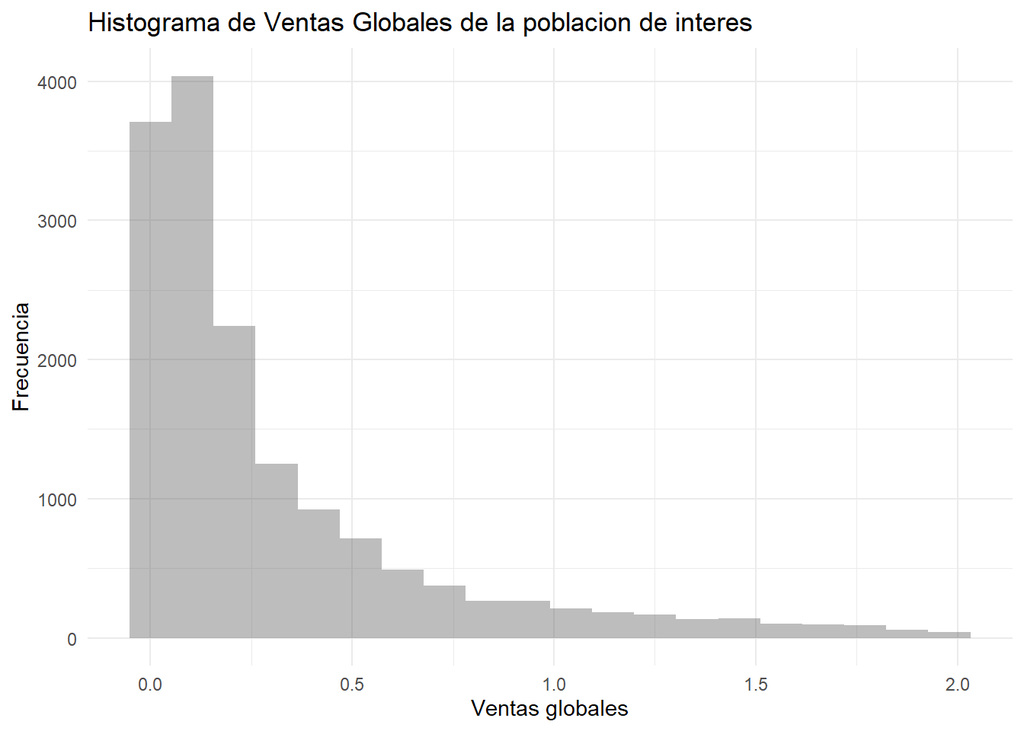

```r
df <- data.vg.pobint

# Histograma agrupado por categoría
ggplot(df , aes(x = Global_Sales) ) +
  geom_histogram(alpha = 0.4, bins = 20) +
  labs(title = "Histograma de Ventas Globales de la poblacion de interes",
       x = "Ventas globales",
       y = "Frecuencia") +
  theme_minimal()
```

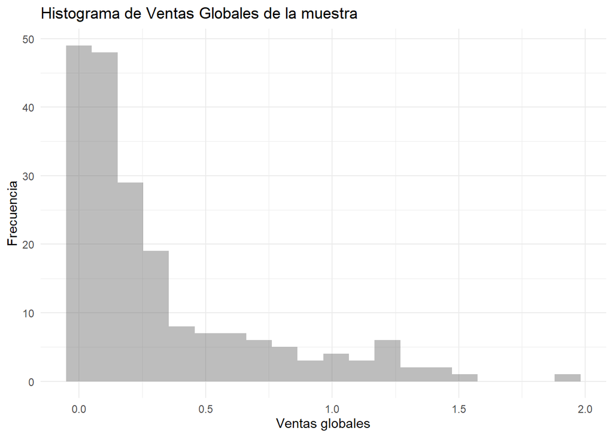

```r
df <- data.muestra

# Histograma agrupado por categoría
ggplot(df , aes(x = Global_Sales) ) +
  geom_histogram(alpha = 0.4, bins = 20) +
  labs(title = "Histograma de Ventas Globales de la muestra",
       x = "Ventas globales",
       y = "Frecuencia") +
  theme_minimal()
```

```r
summary(df)
```

```
##       Rank           Name              Platform       Year
##  Min.   :  885   Length:200         PS2    :33   Min.   :1983
##  1st Qu.: 4888   Class :character   DS     :27   1st Qu.:2003
##  Median : 8486   Mode  :character   PC     :18   Median :2007
##  Mean   : 8776                      Wii    :15   Mean   :2006
##  3rd Qu.:12794                      PS     :14   3rd Qu.:2010
##  Max.   :16588                      PS3    :13   Max.   :2016
##                                     (Other):80
##     Genre            Publisher            NA_Sales         EU_Sales
##  Length:200         Length:200         Min.   :0.0000   Min.   :0.0000
##  Class :character   Class :character   1st Qu.:0.0000   1st Qu.:0.0000
##  Mode  :character   Mode  :character   Median :0.0700   Median :0.0200
##                                        Mean   :0.1563   Mean   :0.0789
##                                        3rd Qu.:0.1900   3rd Qu.:0.0800
##                                        Max.   :1.4200   Max.   :0.7700
##
##     JP_Sales       Other_Sales       Global_Sales
##  Min.   :0.0000   Min.   :0.00000   Min.   :0.0100
##  1st Qu.:0.0000   1st Qu.:0.00000   1st Qu.:0.0600
##  Median :0.0000   Median :0.01000   Median :0.1600
##  Mean   :0.0498   Mean   :0.02885   Mean   :0.3145
##  3rd Qu.:0.0300   3rd Qu.:0.03000   3rd Qu.:0.3950
##  Max.   :0.7500   Max.   :0.60000   Max.   :1.9400
##
```

Muestreo:

```r
set.seed(123)
indices_muestra <- sample(1:5,2,replace = FALSE)
df[indices_muestra,]
```

```
##        Rank                          Name Platform Year    Genre
## 11594 12635                  Killing Zone       PS 1996 Fighting
## 3721   4626 Jikkyou Powerful Pro Yakyuu 6      N64 1999   Sports
##                          Publisher NA_Sales EU_Sales JP_Sales Other_Sales
## 11594        Acclaim Entertainment     0.03     0.02     0.00        0.00
## 3721  Konami Digital Entertainment     0.00     0.00     0.39        0.03
##       Global_Sales
## 11594         0.06
## 3721          0.42
```

#TAREA

# Población de interés: ventas globales < 2 millones

```r
data.vg.pobint <- filter(data.vg, Global_Sales < 2)
```

# Crear la nueva variable Peso_NA

```r
data.vg.pobint <- data.vg.pobint %>%
  mutate(Peso_NA = ifelse(Global_Sales > 0, NA_Sales / Global_Sales, NA))
```

# Verificar valores

```r
summary(data.vg.pobint$Peso_NA)
```

```
##    Min. 1st Qu.  Median    Mean 3rd Qu.    Max.
##  0.0000  0.0000  0.5000  0.4522  0.7500  1.0000
```

#Interpretación: #Valores cercanos a 1 → el juego depende casi completamente del mercado norteamericano. #Valores cercanos a 0 → las ventas provienen sobre todo de otras regiones.

```r
set.seed(101)
N <- nrow(data.vg.pobint)
```

# Muestra 1

```r
indices_m1 <- sample(1:N, 500, replace = TRUE)
muestra1 <- data.vg.pobint[indices_m1, ]
```

# Muestra 2

```r
set.seed(202)
indices_m2 <- sample(1:N, 500, replace = TRUE)
muestra2 <- data.vg.pobint[indices_m2, ]
```

# Estadísticas básicas

```r
summary(muestra1$Peso_NA)
```

```
##    Min. 1st Qu.  Median    Mean 3rd Qu.    Max.
##  0.0000  0.0000  0.4908  0.4406  0.7500  1.0000
```

```r
summary(muestra2$Peso_NA)
```

```
##    Min. 1st Qu.  Median    Mean 3rd Qu.    Max.
##  0.0000  0.0000  0.4848  0.4279  0.7357  1.0000
```

#Interpretación: #Como las medias de la muestra 1 y 2 se asemejan a la media poblacional de Peso_NA, esto demuestra que el muestreo es representativo.

```r
summary(data.vg.pobint$Peso_NA)
```

```
##    Min. 1st Qu.  Median    Mean 3rd Qu.    Max.
##  0.0000  0.0000  0.5000  0.4522  0.7500  1.0000
```

# Comparar medias y desviaciones

```r
media_pob <- mean(data.vg.pobint$Peso_NA, na.rm = TRUE)
media_m1 <- mean(muestra1$Peso_NA, na.rm = TRUE)
media_m2 <- mean(muestra2$Peso_NA, na.rm = TRUE)
cat("Media población:", round(media_pob,3), "\n")
```

```
## Media población: 0.452
```

```r
cat("Media muestra 1:", round(media_m1,3), "\n")
```

```
## Media muestra 1: 0.441
```

```r
cat("Media muestra 2:", round(media_m2,3), "\n")
```

```
## Media muestra 2: 0.428
```

#Ya que las tres medias son similares, esto indica que el muestreo fue realizado correctamente y la variable está bien distribuida.

# Graficar población

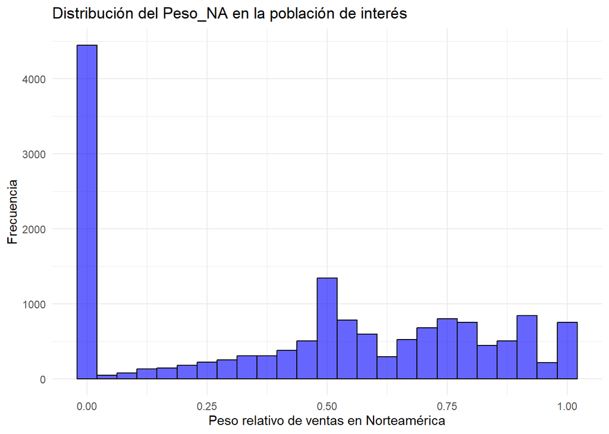

```r
ggplot(data.vg.pobint, aes(x = Peso_NA)) +
  geom_histogram(fill = "blue", color = "black", bins = 25, alpha = 0.6) +
  labs(title = "Distribución del Peso_NA en la población de interés",
       x = "Peso relativo de ventas en Norteamérica",
       y = "Frecuencia") +
  theme_minimal()
```

# Graficar muestras

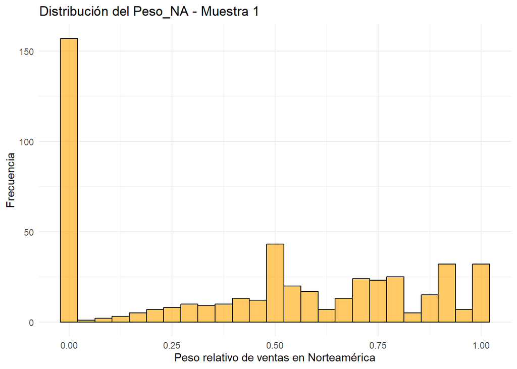

```r
ggplot(muestra1, aes(x = Peso_NA)) +
  geom_histogram(fill = "orange", color = "black", bins = 25, alpha = 0.6) +
  labs(title = "Distribución del Peso_NA - Muestra 1",
       x = "Peso relativo de ventas en Norteamérica",
       y = "Frecuencia") +
  theme_minimal()
```

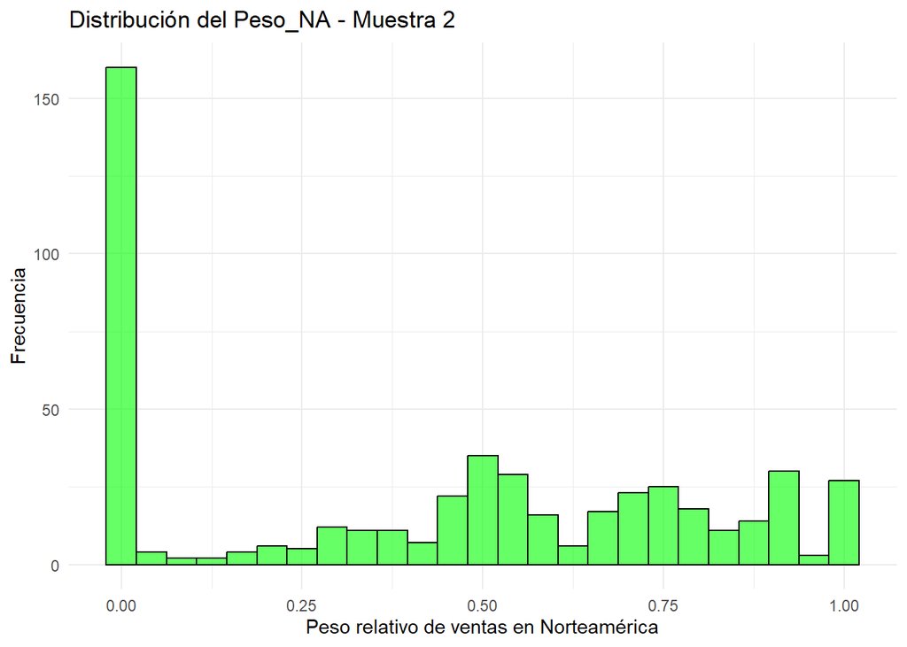

```r
ggplot(muestra2, aes(x = Peso_NA)) +
  geom_histogram(fill = "green", color = "black", bins = 25, alpha = 0.6) +
  labs(title = "Distribución del Peso_NA - Muestra 2",
       x = "Peso relativo de ventas en Norteamérica",
       y = "Frecuencia") +
  theme_minimal()
```

#Observaciones y Conclusiones #En este análisis se estudió la variable Peso_NA, que representa el porcentaje de ventas globales de videojuegos que provienen de Norteamérica. Se trabajó con la población de juegos que vendieron menos de 2 millones de copias. #Se tomaron dos muestras aleatorias de 500 videojuegos y se compararon con la población. Se observó que muchas ventas se concentran únicamente dentro o fuera de Norteamérica (valores de 0 o 1 en Peso_NA). Esto indica que el mercado está segmentado y que no todos los videojuegos se venden de forma equilibrada en todas las regiones. #Las muestras reflejan bien el comportamiento de la población, lo cual valida el proceso de muestreo y permite obtener conclusiones representativas.